# 2. Discretized Singular Value Decomposition (`dSVD`)

Koki Tsuyuzaki

Laboratory for Bioinformatics Research, RIKEN Center for Biosystems Dynamics Research  
k.t.the-answer@hotmail.co.jp

2023-03-07

# Introduction

In this vignette, we consider approximating a matrix as a product of two low-rank matrices (a.k.a., factor matrices).

Test data is available from `toyModel`.

```r
library("dcTensor")
X <- dcTensor::toyModel("dSVD")
```

You will see that there are five blocks in the data matrix as follows.

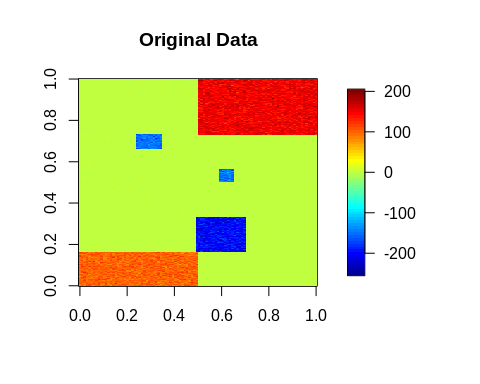

```r
suppressMessages(library("fields"))
image.plot(X, main="Original Data", legend.mar=8)
```

# Semi-Ternary Matrix Factorization (STMF)

Here, we introduce the ternary regularization to take {-1,0,1} values in $U$ as below:

$$X \approx U V' \ \mathrm{s.t.}\ U \in \{-1,0,1\},$$
where $X$ ($N \times M$) is a data matrix, $U$ ($N \times J$) is a ternary score matrix, and $V$ ($M \times J$) is a loading matrix. In `dcTensor` package, the object function is optimized by combining gradient-descent algorithm (Tsuyuzaki 2020) and ternary regularization.

## Basic Usage

In STMF, a rank parameter $J$ ($\leq \min(N, M)$) is needed to be set in advance. Other settings such as the number of iterations (`num.iter`) are also available. For the details of arguments of dSVD, see `?dSVD`. After the calculation, various objects are returned by `dSVD`. STMF is achieved by specifying the ternary regularization parameter as a large value like the below:

```r
set.seed(123456)
out_STMF <- dSVD(X, Ter_U=1E+10, J=5)
str(out_STMF, 2)
```

```
## List of 6
##  $ U            : num [1:100, 1:5] 0.00592 0.00582 0.00626 0.00641 0.00611 ...
##  $ V            : num [1:300, 1:5] 89.8 94.8 93.6 101 87.6 ...
##  $ RecError     : Named num [1:101] 1.00e-09 4.24e+05 3.67e+05 3.63e+05 3.65e+05 ...
##   ..- attr(*, "names")= chr [1:101] "offset" "1" "2" "3" ...
##  $ TrainRecError: Named num [1:101] 1.00e-09 4.24e+05 3.67e+05 3.63e+05 3.65e+05 ...
##   ..- attr(*, "names")= chr [1:101] "offset" "1" "2" "3" ...
##  $ TestRecError : Named num [1:101] 1e-09 0e+00 0e+00 0e+00 0e+00 0e+00 0e+00 0e+00 0e+00 0e+00 ...
##   ..- attr(*, "names")= chr [1:101] "offset" "1" "2" "3" ...
##  $ RelChange    : Named num [1:101] 1.00e-09 9.70e-01 1.55e-01 1.25e-02 4.53e-03 ...
##   ..- attr(*, "names")= chr [1:101] "offset" "1" "2" "3" ...
```

The reconstruction error (`RecError`) and relative error (`RelChange`, the amount of change from the reconstruction error in the previous step) can be used to diagnose whether the calculation is converged or not.

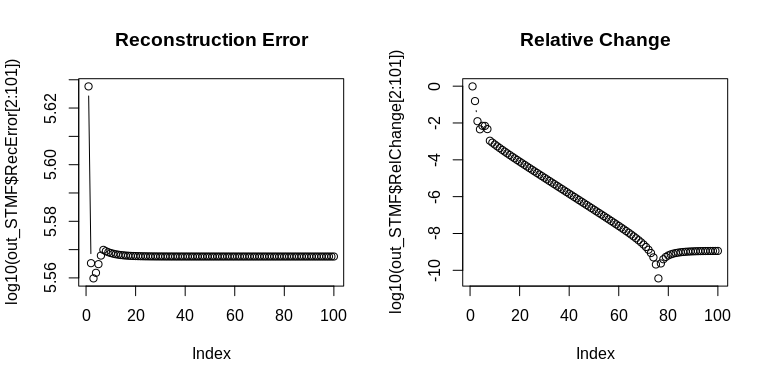

```r
layout(t(1:2))
plot(log10(out_STMF$RecError[2:101]), type="b", main="Reconstruction Error")
plot(log10(out_STMF$RelChange[2:101]), type="b", main="Relative Change")
```

The product of $U$ and $V$ shows whether the original data is well-recovered by `dSVD`.

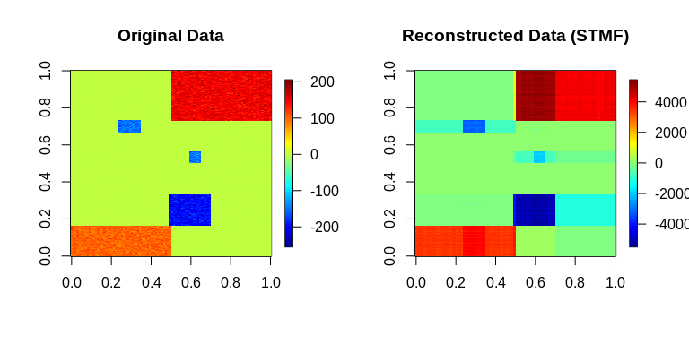

```r
recX <- out_STMF$U %*% t(out_STMF$V)
layout(t(1:2))
image.plot(X, main="Original Data", legend.mar=8)
image.plot(recX, main="Reconstructed Data (STMF)", legend.mar=8)
```

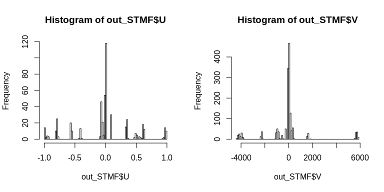

```r
layout(t(1:2))
hist(out_STMF$U, breaks=100)
hist(out_STMF$V, breaks=100)
```

# References

Tsuyuzaki, K. et al. 2020. “Benchmarking Principal Component Analysis for Large-Scale Single-Cell RNA-Sequencing.” *BMC Genome Biology* 21(1): 9.